# MCV1 Worldwide & The African Region

```r
#detach("package:plyr", unload=TRUE)
library(dplyr)
library(rworldmap)
library(ggplot2)
library(tidyverse)
library(scales)
library(xts)
library(zoo)
library(plyr)
library(forecast)
library(directlabels)
library("ggpubr")
library(multcomp)
library(rpivotTable)
```

```r
#setwd("C:\Users\flare\Documents\Research")
getwd()
```

```
[1] "C:/Users/flare/Documents/Research"
```

# Data importing

```r
df <- read.csv(file="finaldata.csv", header=TRUE, sep="," )
head(df)
```

|  | ï..Cname | Exchange | ISO_code | Region | Vaccine | Year | value |
| --- | --- | --- | --- | --- | --- | --- | --- |
| 1 | Afghanistan | BCG | AFG | EMR | BCG | 1980 | NA |
| 2 | Albania | BCG | ALB | EUR | BCG | 1980 | 93 |
| 3 | Algeria | BCG | DZA | AFR | BCG | 1980 | NA |
| 4 | Angola | BCG | AGO | AFR | BCG | 1980 | NA |
| 5 | Argentina | BCG | ARG | AMR | BCG | 1980 | 62 |
| 6 | Armenia | BCG | ARM | EUR | BCG | 1980 | NA |

```r
# Correct the first column name as Cname
colnames(df)[1] <- "Cname"
head(df)
```

|  | Cname | Exchange | ISO_code | Region | Vaccine | Year | value |
| --- | --- | --- | --- | --- | --- | --- | --- |
| 1 | Afghanistan | BCG | AFG | EMR | BCG | 1980 | NA |
| 2 | Albania | BCG | ALB | EUR | BCG | 1980 | 93 |
| 3 | Algeria | BCG | DZA | AFR | BCG | 1980 | NA |
| 4 | Angola | BCG | AGO | AFR | BCG | 1980 | NA |
| 5 | Argentina | BCG | ARG | AMR | BCG | 1980 | 62 |
| 6 | Armenia | BCG | ARM | EUR | BCG | 1980 | NA |

```r
# inspect data
str(df)
```

```
'data.frame':   94468 obs. of  7 variables:
 $ Cname   : Factor w/ 194 levels "Afghanistan",..: 1 2 3 5 7 8 10 11 14 16 ...
 $ Exchange: Factor w/ 14 levels "BCG","DTP1","DTP3",..: 1 1 1 1 1 1 1 1 1 1 ...
 $ ISO_code: Factor w/ 194 levels "AFG","AGO","ALB",..: 1 3 51 2 6 7 10 11 16 21 ...
 $ Region  : Factor w/ 6 levels "AFR","AMR","EMR",..: 3 4 1 1 2 4 4 4 5 4 ...
 $ Vaccine : Factor w/ 14 levels "BCG","DTP1","DTP3",..: 1 1 1 1 1 1 1 1 1 1 ...
 $ Year    : int  1980 1980 1980 1980 1980 1980 1980 1980 1980 1980 ...
 $ value   : int  NA 93 NA NA 62 NA 90 NA NA NA ...
```

```r
head(df)
```

|  | Cname | Exchange | ISO_code | Region | Vaccine | Year | value |
| --- | --- | --- | --- | --- | --- | --- | --- |
| 1 | Afghanistan | BCG | AFG | EMR | BCG | 1980 | NA |
| 2 | Albania | BCG | ALB | EUR | BCG | 1980 | 93 |
| 3 | Algeria | BCG | DZA | AFR | BCG | 1980 | NA |
| 4 | Angola | BCG | AGO | AFR | BCG | 1980 | NA |
| 5 | Argentina | BCG | ARG | AMR | BCG | 1980 | 62 |
| 6 | Armenia | BCG | ARM | EUR | BCG | 1980 | NA |

```r
tail(df)
```

|  | Cname | Exchange | ISO_code | Region | Vaccine | Year | value |
| --- | --- | --- | --- | --- | --- | --- | --- |
| 94463 | Suriname | YFV | SUR | AMR | YFV | 2017 | 79 |
| 94464 | Togo | YFV | TGO | AFR | YFV | 2017 | 91 |
| 94465 | Trinidad and Tobago | YFV | TTO | AMR | YFV | 2017 | 95 |
| 94466 | Uganda | YFV | UGA | AFR | YFV | 2017 | NA |
| 94467 | United Republic of Tanzania | YFV | TZA | AFR | YFV | 2017 | NA |
| 94468 | Venezuela (Bolivarian Republic of) | YFV | VEN | AMR | YFV | 2017 | 83 |

```r
# convert missing values to zero
df[is.na(df)] <- 0
```

# RQ1. What is the worldwide trend of immunization?

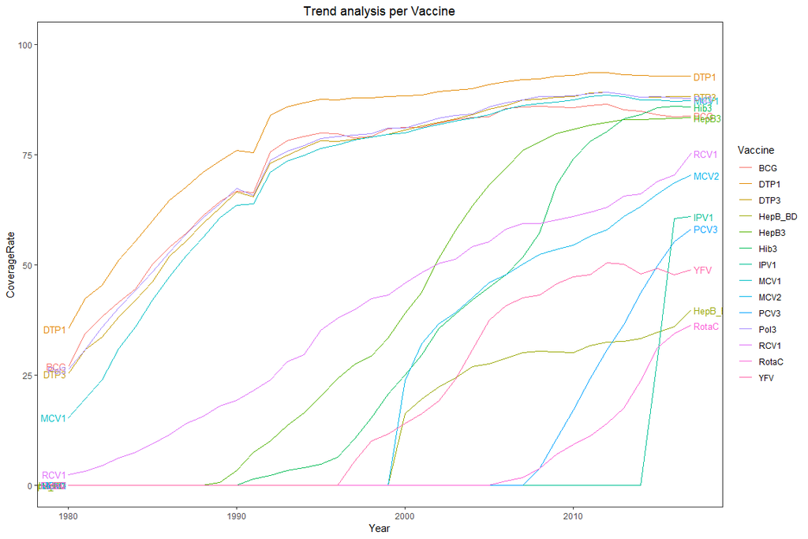

```r
vaccine <- df %>%
  group_by(Vaccine, Year) %>%
  dplyr::summarize(CoverageRate = mean(value, na.rm=TRUE))
ggplot(vaccine, (aes(x = Year, y = CoverageRate, group = Vaccine, colour = Vaccine))) +
  geom_line() +
  geom_dl(aes(label = Vaccine), method = list(dl.trans(x = x + 0.1), "last.points", cex = 0.8)) +
  geom_dl(aes(label = Vaccine), method = list(dl.trans(x = x - 0.1), "first.points", cex = 0.8)) +
  scale_y_continuous(limits = c(0, 100)) +
  theme(axis.text.x = element_text(angle = 45),legend.position="bottom") +
  theme_bw() +
  theme(panel.grid.major = element_blank(),
        panel.grid.minor = element_blank()) +
  ggtitle("Trend analysis per Vaccine") +
  theme(plot.title = element_text(hjust = 0.5)) +
  guides(fill=FALSE)
```

# Select MCV1 only

```r
# since my analysis focuses on mealses and its vaccine (MCV1), select rows with this condition
df <- subset(df, Vaccine == "MCV1")
```

```r
# the focus is on world regions so let's find out the six world regions
levels(df$Region)
```

```
[1] "AFR"  "AMR"  "EMR"  "EUR"  "SEAR" "WPR"
```

- African Region (AFR)
- Region of the Americas (AMR)
- South-East Asia Region (SEAR)
- European Region (EUR)
- Eastern Mediterranean Region (EMR)
- Western Pacific Region (WPR)

```r
head(df)
```

|  | Cname | Exchange | ISO_code | Region | Vaccine | Year | value |
| --- | --- | --- | --- | --- | --- | --- | --- |
| 1277 | Afghanistan | MCV1 | AFG | EMR | MCV1 | 1980 | 11 |
| 1278 | Albania | MCV1 | ALB | EUR | MCV1 | 1980 | 90 |
| 1279 | Algeria | MCV1 | DZA | AFR | MCV1 | 1980 | 0 |
| 1280 | Andorra | MCV1 | AND | EUR | MCV1 | 1980 | 0 |
| 1281 | Angola | MCV1 | AGO | AFR | MCV1 | 1980 | 0 |
| 1282 | Antigua and Barbuda | MCV1 | ATG | AMR | MCV1 | 1980 | 0 |

```r
global <- df %>%
                group_by(Year) %>%
                dplyr::summarize(CoverageRate = mean(value, na.rm=TRUE))
## Add a column indicating whether the category should be highlighted
X <- global %>% mutate( ToHighlight = ifelse( Year >= 2008 & Year <= 2018, "yes", "no" ) )
region <- df %>%
  group_by(Region, Year) %>%
  dplyr::summarize(CoverageRate = mean(value, na.rm=TRUE))
region <- region %>%
  mutate(CoverageRate = if_else(is.na(CoverageRate), 0, CoverageRate))
head(region)
```

| Region | Year | CoverageRate |
| --- | --- | --- |
| AFR | 1980 | 7.978723 |
| AFR | 1981 | 16.510638 |
| AFR | 1982 | 20.106383 |
| AFR | 1983 | 25.957447 |
| AFR | 1984 | 29.021277 |
| AFR | 1985 | 37.404255 |

# RQ2. What is the trend of MCV1 immunization in terms of regions (African, Americas, South-East Asia, European, Eastern Mediterranean, and Western Pacific)?

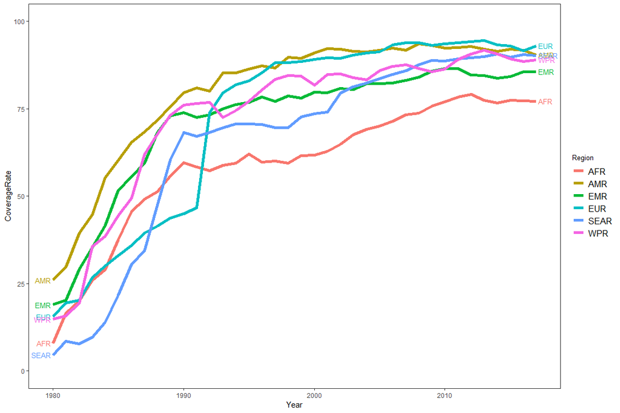

```r
region <- df %>%
  group_by(Region, Year) %>%
  dplyr::summarize(CoverageRate = mean(value, na.rm=TRUE))
ggplot(region, (aes(x = Year, y = CoverageRate, group = Region, colour = Region))) +
  geom_line(size=2) +
  geom_dl(aes(label = Region), method = list(dl.trans(x = x + 0.1), "last.points", cex = 0.8)) +
  geom_dl(aes(label = Region), method = list(dl.trans(x = x - 0.1), "first.points", cex = 0.8)) +
  scale_y_continuous(limits = c(0, 100)) +
  theme(axis.text.x = element_text(angle = 45),legend.position="bottom") +
  theme_bw() +
  theme(panel.grid.major = element_blank(),
        panel.grid.minor = element_blank()) +
  #ggtitle("Trend analysis per Vaccine") +
  theme(plot.title = element_text(size = 12, face = "bold", hjust = 0.5),
        legend.title=element_text(size=10),
        legend.text=element_text(size=12)) +
  guides(fill=FALSE)
```

# RQ2

# Worldwide Map of MCV1 Coverage Rate

```
194 codes from your data successfully matched countries in the map
0 codes from your data failed to match with a country code in the map
49 codes from the map weren't represented in your data
```

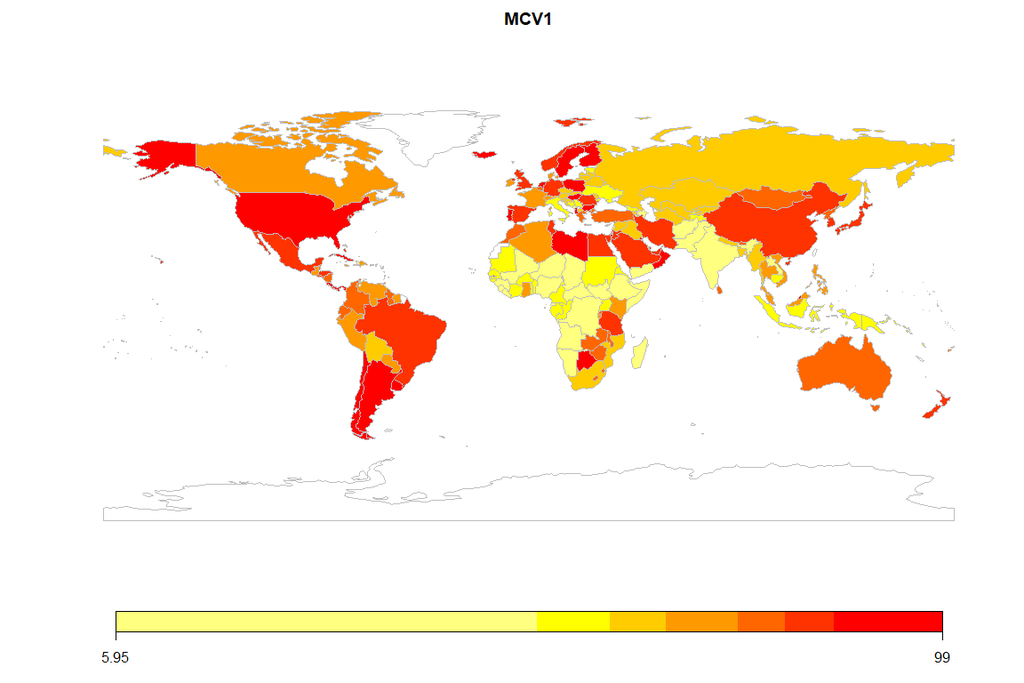

```r
# Function to visualize coverage rate in a global map
create_map <- function(vaccine_type) {

  vaccine_name <- filter(df, Vaccine == vaccine_type)

  country <- vaccine_name %>%
    group_by(ISO_code) %>%
    dplyr::summarize(CoverageRate = mean(value, na.rm=TRUE))

  sPDF <- joinCountryData2Map( country
                               ,joinCode = "ISO3"
                               ,nameJoinColumn = "ISO_code")

  mapCountryData(sPDF,
                 nameColumnToPlot='CoverageRate',
                 mapTitle=vaccine_type)

  par(mai=c(0,0,0.2,0),xaxs="i",yaxs="i")

}
create_map('MCV1')
```

# RQ 3. What are the countries with very low MCV1 coverage rates? What countries are considered “outliers”, those countries with low coverage rates?

```r
detach("package:plyr", unload=TRUE)
```

[output not shown]

```r
df %>%
  group_by(Region) %>%
  summarize(n())
```

| Region | n() |
| --- | --- |
| AFR | 1786 |
| AMR | 1330 |
| EMR | 798 |
| EUR | 2014 |
| SEAR | 418 |
| WPR | 1026 |

```r
df %>%
  group_by(Region) %>%
  summarize(n_distinct(Cname))
```

| Region | n_distinct(Cname) |
| --- | --- |
| AFR | 47 |
| AMR | 35 |
| EMR | 21 |
| EUR | 53 |
| SEAR | 11 |
| WPR | 27 |

```r
df %>%
  group_by(Region) %>%
  summarize(coverage_rate = mean(value, na.rm = TRUE))
```

| Region | coverage_rate |
| --- | --- |
| AFR | 59.09127 |
| AMR | 80.07744 |
| EMR | 71.43233 |
| EUR | 71.78649 |
| SEAR | 65.14115 |
| WPR | 72.98148 |

**Worldwide**

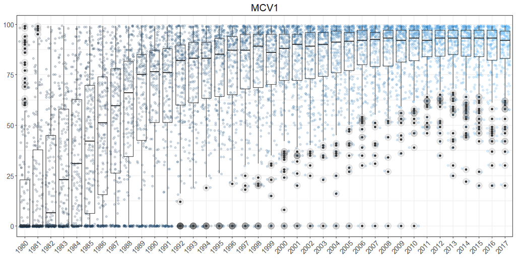

```r
get_outliers <- function(vaccine_type) {

  vaccine_name <- filter(df, Vaccine == vaccine_type)

  country <- vaccine_name %>%
    group_by(Year, ISO_code) %>%
    dplyr::summarize(CoverageRate = mean(value, na.rm=TRUE))

  out <- ggplot(country, aes(x = factor(Year), y = CoverageRate)) +
    geom_boxplot() +
    ggtitle(vaccine_type) +
    geom_point(aes(color=Year), alpha=0.2, position='jitter') +
    geom_boxplot(outlier.size=5, alpha=0.1) +
    theme_bw() +
    theme(plot.title = element_text(hjust = 0.5)) +
    theme(axis.text.x = element_text(angle = 45, hjust = 1)) +
    theme(legend.position="none", text = element_text(size=14))+
    theme(axis.title.x=element_blank(), axis.title.y=element_blank())

  print(out)
}
get_outliers('MCV1')
```

The chart above shows something very significant happening that while there is an increase in MCV1 immunization worldwide, there are also many countries far behind that worldwide trend.

## Comparing Two Regions: Europe (EUR) & Africa (AFR)

**Europe Region**

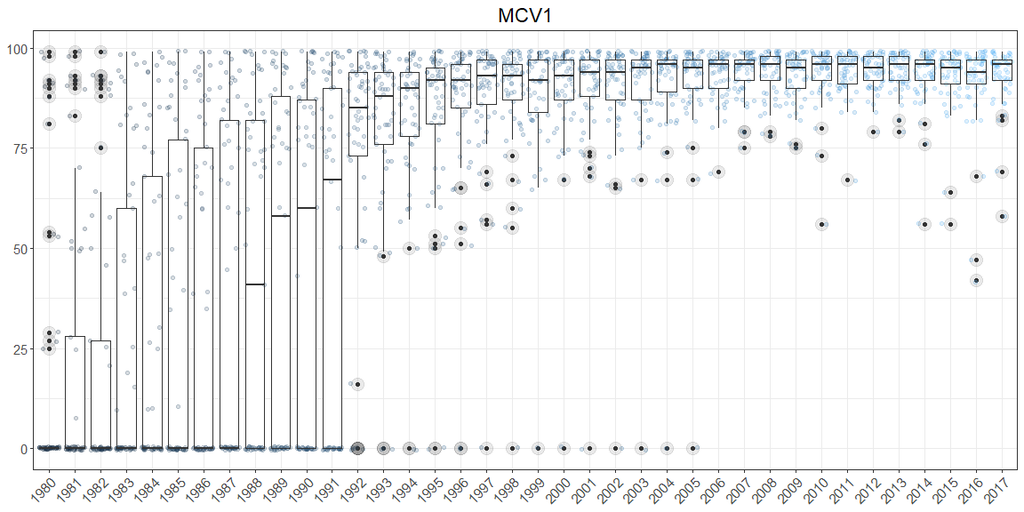

```r
get_outliers <- function(vaccine_type, region_name) {

  vaccine_name <- filter(df, Vaccine == vaccine_type, Region == region_name)

  country <- vaccine_name %>%
    group_by(Year, ISO_code) %>%
    dplyr::summarize(CoverageRate = mean(value, na.rm=TRUE))

  out <- ggplot(country, aes(x = factor(Year), y = CoverageRate)) +
    geom_boxplot() +
    ggtitle(vaccine_type) +
    geom_point(aes(color=Year), alpha=0.2, position='jitter') +
    geom_boxplot(outlier.size=5, alpha=0.1) +
    theme_bw() +
    theme(plot.title = element_text(hjust = 0.5)) +
    theme(axis.text.x = element_text(angle = 45, hjust = 1)) +
    theme(legend.position="none", text = element_text(size=14))+
    theme(axis.title.x=element_blank(), axis.title.y=element_blank())

  print(out)
}
get_outliers('MCV1', 'EUR')
```

The chart above shows a strong performance of European countries in MCV1 immunization - Variation among the counrties is very minimal, indicating that most countries are doing very well.

**African Region**

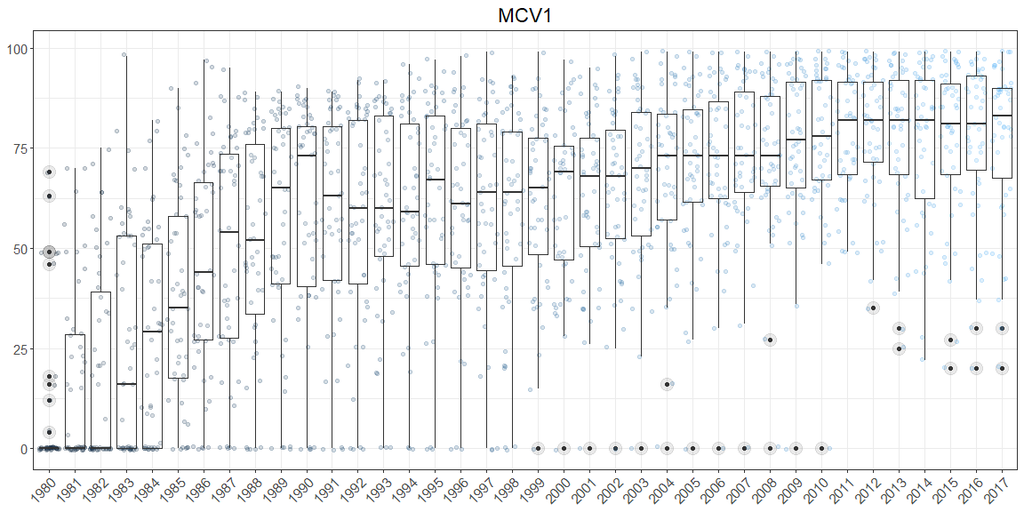

```r
get_outliers('MCV1', 'AFR')
```

```r
rpivotTable(df)
```

[interactive table not shown]

### Let’s find out what countries are the outliers

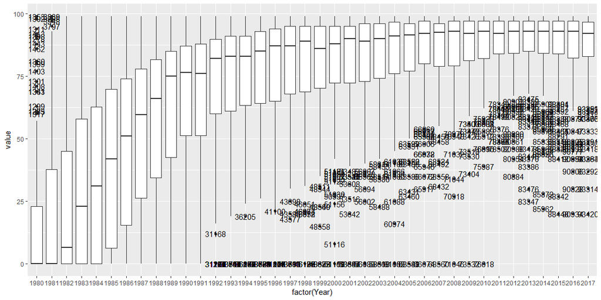

```r
df1 <- df
df1$Year <- as.factor(df1$Year)
is_outlier <- function(x) {
  return(x < quantile(x, 0.25) - 1.5 * IQR(x) | x > quantile(x, 0.75) + 1.5 * IQR(x))
}
dat <- df1 %>%
        tibble::rownames_to_column(var="outlier") %>%
        group_by(Year) %>%
        mutate(is_outlier=ifelse(is_outlier(value), value, as.numeric(NA)))

dat$outlier[which(is.na(dat$is_outlier))] <- as.numeric(NA)
ggplot(dat, aes(y=value, x=factor(Year))) + geom_boxplot() + geom_text(aes(label=outlier),na.rm=TRUE,nudge_y=0.05)
```

```r
# print those outliers
df2 <- dat
df3 <- df2[!is.na(df2$outlier),]
outlier_country <- df3 %>%
  group_by(Year, Region, Cname) %>%
  dplyr::summarize(CoverageRate = mean(value, na.rm=TRUE))
nrow(outlier_country)
```

```
[1] 305
```

```r
outlier_country
```

| Year | Region | Cname | CoverageRate |
| --- | --- | --- | --- |
| 1980 | AFR | Botswana | 63 |
| 1980 | AFR | Gambia | 69 |
| 1980 | AMR | Argentina | 61 |
| 1980 | AMR | Chile | 94 |
| 1980 | AMR | Costa Rica | 60 |
| 1980 | AMR | Panama | 71 |
| 1980 | AMR | United States of America (the) | 86 |
| 1980 | EMR | Libya | 61 |
| 1980 | EUR | Albania | 90 |
| 1980 | EUR | Bulgaria | 98 |

[output cut: 295 more lines]

```r
#write.csv(outlier_country, "outlier.csv")
```

Exclude the outliers in 1980 and 1981 from further analysis since they were top performers back then.

```r
outlier_country %>%
  group_by(Year) %>%
  summarize(n())
```

| Year | n() |
| --- | --- |
| 1980 | 19 |
| 1981 | 4 |
| 1992 | 13 |
| 1993 | 8 |
| 1994 | 8 |
| 1995 | 7 |
| 1996 | 8 |
| 1997 | 8 |
| 1998 | 10 |
| 1999 | 8 |

[output cut: 18 more lines]

```r
NA
```

```r
outlier_country_since1982 <- outlier_country %>%
  filter(Year != 1980 & Year != 1981)
outlier_country_since1982
```

| Year | Region | Cname | CoverageRate |
| --- | --- | --- | --- |
| 1992 | AFR | Eritrea | 0 |
| 1992 | AFR | Ethiopia | 12 |
| 1992 | AFR | Liberia | 0 |
| 1992 | AFR | Sierra Leone | 0 |
| 1992 | AFR | South Sudan | 0 |
| 1992 | EUR | Andorra | 0 |
| 1992 | EUR | Czech Republic | 0 |
| 1992 | EUR | Estonia | 0 |
| 1992 | EUR | Montenegro | 0 |
| 1992 | EUR | Slovakia | 0 |

[output cut: 272 more lines]

```r
NA
```

```r
outlier_country_since1982 %>%
  group_by(Year) %>%
  summarize(n())
```

| Year | n() |
| --- | --- |
| 1992 | 13 |
| 1993 | 8 |
| 1994 | 8 |
| 1995 | 7 |
| 1996 | 8 |
| 1997 | 8 |
| 1998 | 10 |
| 1999 | 8 |
| 2000 | 14 |
| 2001 | 11 |

[output cut: 16 more lines]

```r
outlier_list <- outlier_country_since1982 %>%
  group_by(Year, Region) %>%
  summarize(count = n())
outlier_list
```

| Year | Region | count |
| --- | --- | --- |
| 1992 | AFR | 5 |
| 1992 | EUR | 6 |
| 1992 | SEAR | 1 |
| 1992 | WPR | 1 |
| 1993 | AFR | 3 |
| 1993 | EUR | 3 |
| 1993 | SEAR | 1 |
| 1993 | WPR | 1 |
| 1994 | AFR | 4 |
| 1994 | EUR | 2 |

[output cut: 89 more lines]

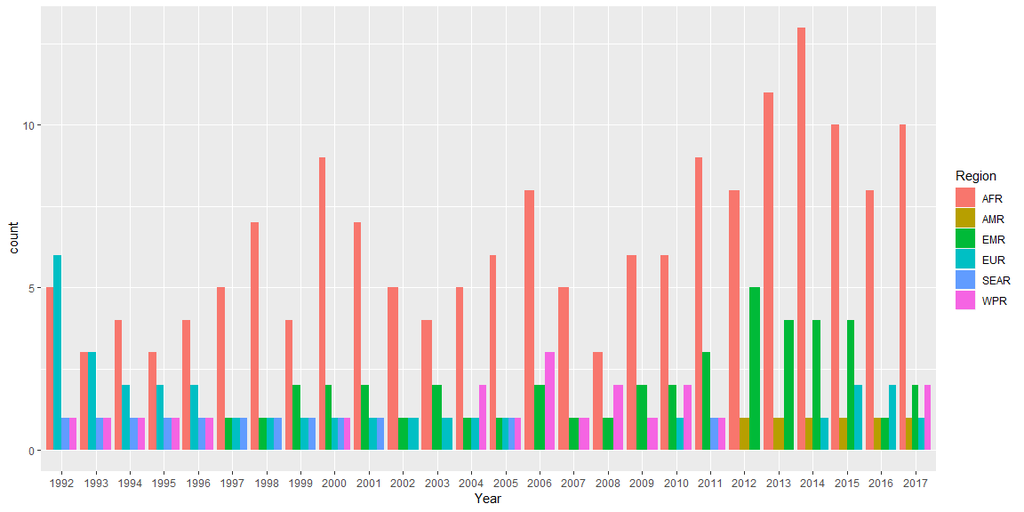

```r
ggplot(outlier_list, aes(Year, count)) +
  geom_bar(aes(fill = Region), position = "dodge", stat="identity")
```

```r
NA
```

### Conclusion

**More outliers in AFR than any other regions over the past three decades. This trend has not slow down**

# Hypothesis Testing

- AFR is lower than other regions in terms of MCV1 immunization (due to lack of political and economic infrastructure)

Before hypothesis testing, let’s visualize the data http://www.sthda.com/english/wiki/one-way-anova-test-in-r

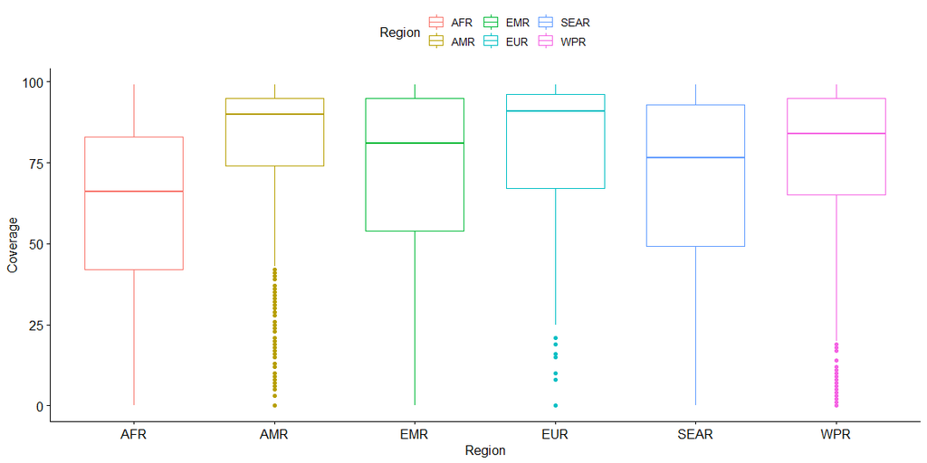

```r
# barplot
ggboxplot(df, x = "Region", y = "value",
          color = "Region", ylab = "Coverage", xlab = "Region")
```

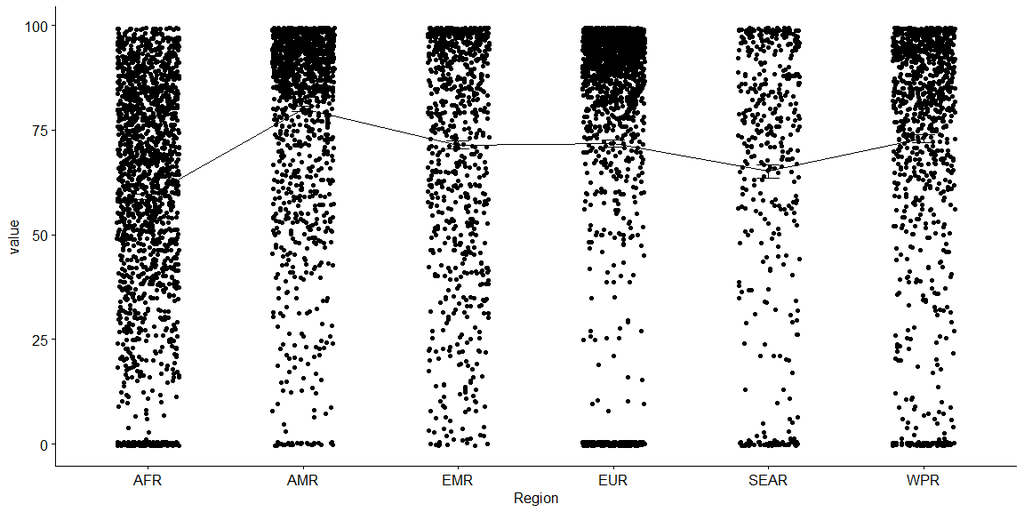

```r
# Mean plots: Plot weight by group; Add error bars: mean_se
# (other values include: mean_sd, mean_ci, median_iqr, ....)
ggline(df, x = "Region", y = "value",
       add = c("mean_se", "jitter"),
       ylab = "value", xlab = "Region")
```

### Analysis of Variance (ANOVA)

```r
anova <- aov(value ~ Region, data = df)
summary(anova)
```

```
              Df  Sum Sq Mean Sq F value Pr(>F)
Region         5  374643   74929   78.85 <2e-16 ***
Residuals   7366 6999871     950
---
Signif. codes:  0 *** 0.001 ** 0.01 * 0.05 . 0.1   1
```

[output not shown]

```r
summary(glht(anova, linfct = mcp(Region = "Tukey")))
```

```
     Simultaneous Tests for General Linear Hypotheses

Multiple Comparisons of Means: Tukey Contrasts


Fit: aov(formula = value ~ Region, data = df)

Linear Hypotheses:
                Estimate Std. Error t value Pr(>|t|)
AMR - AFR == 0   20.9862     1.1165  18.796  < 0.001 ***
EMR - AFR == 0   12.3411     1.3126   9.402  < 0.001 ***
EUR - AFR == 0   12.6952     1.0020  12.670  < 0.001 ***
SEAR - AFR == 0   6.0499     1.6750   3.612  0.00402 **
WPR - AFR == 0   13.8902     1.2076  11.502  < 0.001 ***
EMR - AMR == 0   -8.6451     1.3803  -6.263  < 0.001 ***
EUR - AMR == 0   -8.2909     1.0892  -7.612  < 0.001 ***
SEAR - AMR == 0 -14.9363     1.7286  -8.641  < 0.001 ***
WPR - AMR == 0   -7.0960     1.2809  -5.540  < 0.001 ***
EUR - EMR == 0    0.3542     1.2895   0.275  0.99978
SEAR - EMR == 0  -6.2912     1.8613  -3.380  0.00910 **
WPR - EMR == 0    1.5492     1.4550   1.065  0.89087
SEAR - EUR == 0  -6.6453     1.6569  -4.011  < 0.001 ***
WPR - EUR == 0    1.1950     1.1824   1.011  0.91076
WPR - SEAR == 0   7.8403     1.7888   4.383  < 0.001 ***
---
Signif. codes:  0 *** 0.001 ** 0.01 * 0.05 . 0.1   1
(Adjusted p values reported -- single-step method)
```

```r
pairwise.t.test(df$value, df$Region,
                p.adjust.method = "BH")
```

```
    Pairwise comparisons using t tests with pooled SD

data:  df$value and df$Region

     AFR     AMR     EMR     EUR     SEAR
AMR  < 2e-16 -       -       -       -
EMR  < 2e-16 8.5e-10 -       -       -
EUR  < 2e-16 7.6e-14 0.78358 -       -
SEAR 0.00042 < 2e-16 0.00091 9.2e-05 -
WPR  < 2e-16 5.9e-08 0.33121 0.33452 2.0e-05

P value adjustment method: BH
```

### ANOVA Assumptions

ANOVA has assumptions about the data so let’s check them ()

[output not shown]

[output not shown]

[output not shown]

### Relaxing the homogeneity of variance assumption.

http://www.sthda.com/english/wiki/one-way-anova-test-in-r

```r
pairwise.t.test(df$value, df$Region,
                p.adjust.method = "BH", pool.sd = TRUE)
```

```
    Pairwise comparisons using t tests with pooled SD

data:  df$value and df$Region

     AFR     AMR     EMR     EUR     SEAR
AMR  < 2e-16 -       -       -       -
EMR  < 2e-16 8.5e-10 -       -       -
EUR  < 2e-16 7.6e-14 0.78358 -       -
SEAR 0.00042 < 2e-16 0.00091 9.2e-05 -
WPR  < 2e-16 5.9e-08 0.33121 0.33452 2.0e-05

P value adjustment method: BH
```

### Conclusion

- My first hypothesis is confirmed that AFR is lower than other regions in terms of MCV1 immunization. This finding can be both expected and suprising. To some, this finding may be expected. However, this finding is also alarming that while there has been much progress in worldwid immunization and world population living in extreme poverty is diminishing for the past three decades, the African region is still lagging behind the rest of the world.

**This finding warrants a more fine-grained analysis of MCV1 and the African region.**

# Predicting Next Five Years: Time Series Analysis